# Project_03

Victor Tu

10/20/2021

```
##   currentBet currentOutcome balance
## 1         10              0    9990
## 2         10              0    9980
## 3         10              0    9970
## 4         10              1   10005
## 5         10              0    9995
## 6         20              0    9975
```

## Create below plots:

Plot 1 –> Create a scatter plot using ggplot as shown in the project_03.docx file uploaded to moodle Plot 2 –> Change the win probability to 20% and create plot 2 as shown in project_03.docx file uploaded to moodle Plot 3 –> Create a plot with multiple facets as shown in project_03.docx file uploaded to moodle Plot 4 –> Create a bar plot with multiple facets as shown in project_03.docx file uploaded to moodle

Plot 1:

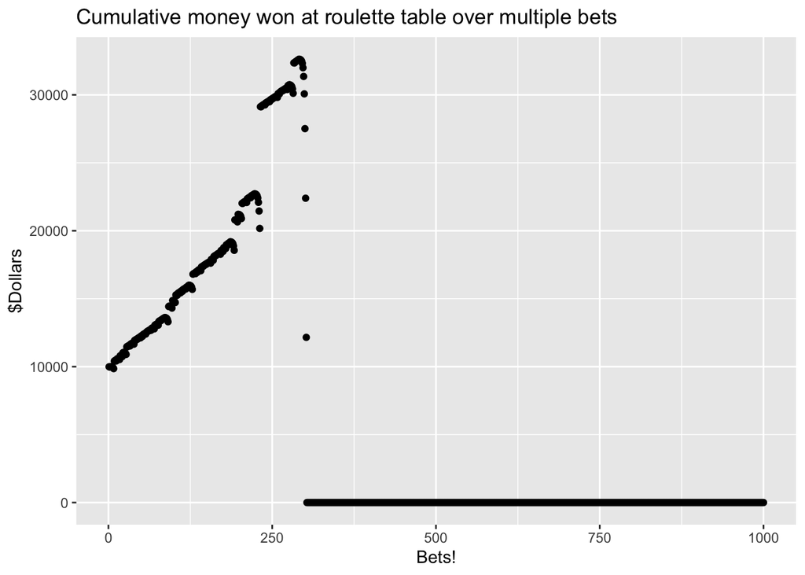

```r
p40 <- ggplot(data = rolls, mapping = aes(x = as.numeric(row.names(rolls)), y = balance)) + geom_point() + labs(title = "Cumulative money won at roulette table over multiple bets", x = "Bets!", y = "$Dollars")
p40
```

In order to produce this plot, I had ggplot read the rolls data and allowed the x-values to be the index of the rolls dataset and the y-values be the balance values.

Plot 2:

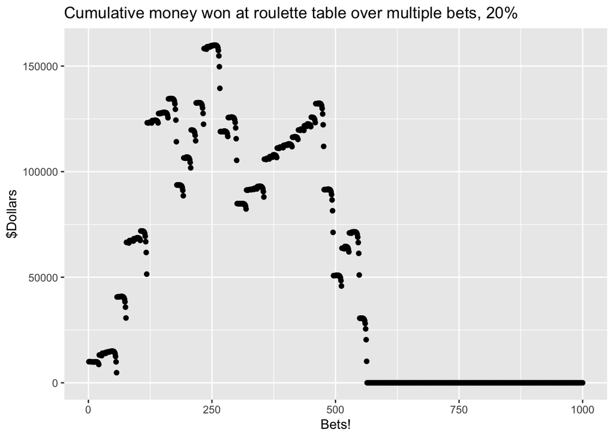

```r
p20 <- ggplot(data = rolls2, mapping = aes(x = as.numeric(row.names(rolls2)), y = balance2)) + geom_point() + labs(title = "Cumulative money won at roulette table over multiple bets, 20%", x = "Bets!", y = "$Dollars")
p20
```

In order to produce this plot, I changed the win probability to 20% and called the ggplot function the same way as Plot 1.

Plot 3:

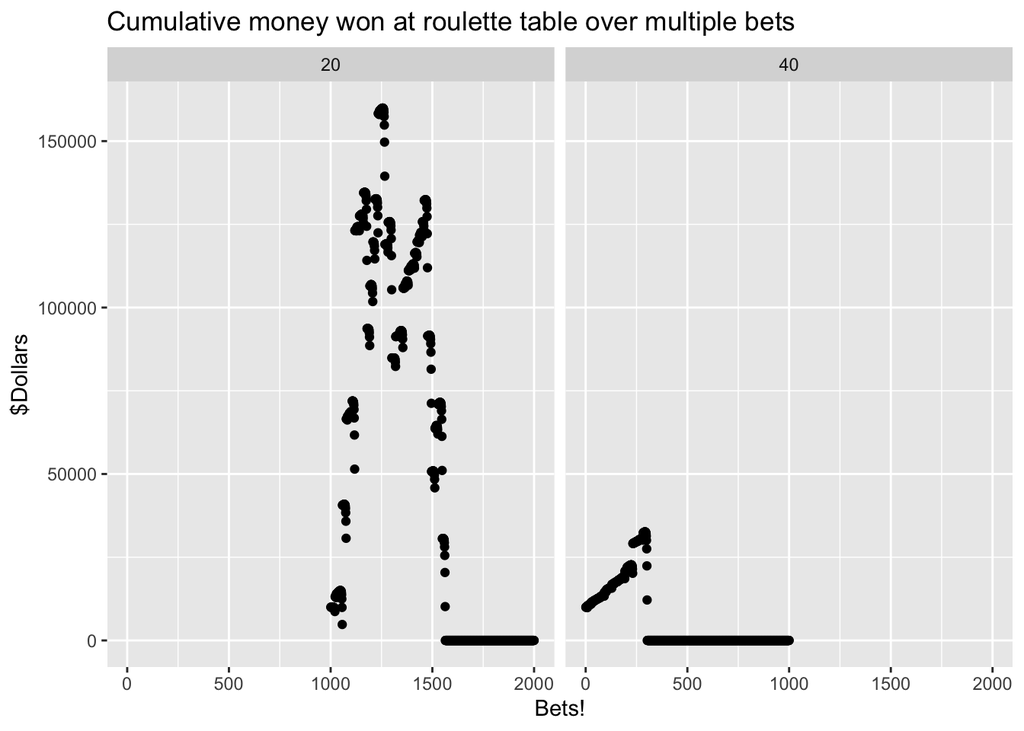

```r
rollsnew = rolls %>% mutate(percentage = 40)
rollsnew20 = rolls2 %>% mutate(percentage = 20)
colnames(rollsnew20) = c("currentBet", "currentOutcome", "balance", "percentage")
rollsplot3 = rbind(rollsnew, rollsnew20)

plot3 = ggplot( rollsplot3 , aes(x = as.numeric(row.names(rollsplot3)), y=balance )) + labs(title = "Cumulative money won at roulette table over multiple bets", x = "Bets!", y = "$Dollars") + geom_point() + facet_grid( ~percentage)
plot3
```

In order to create this plot, I first created a new dataset that appended the 40% dataset to include the 20% dataset. Next, I called the ggplot function to include a facet and filtered based on my made up percentage column.

Plot 4:

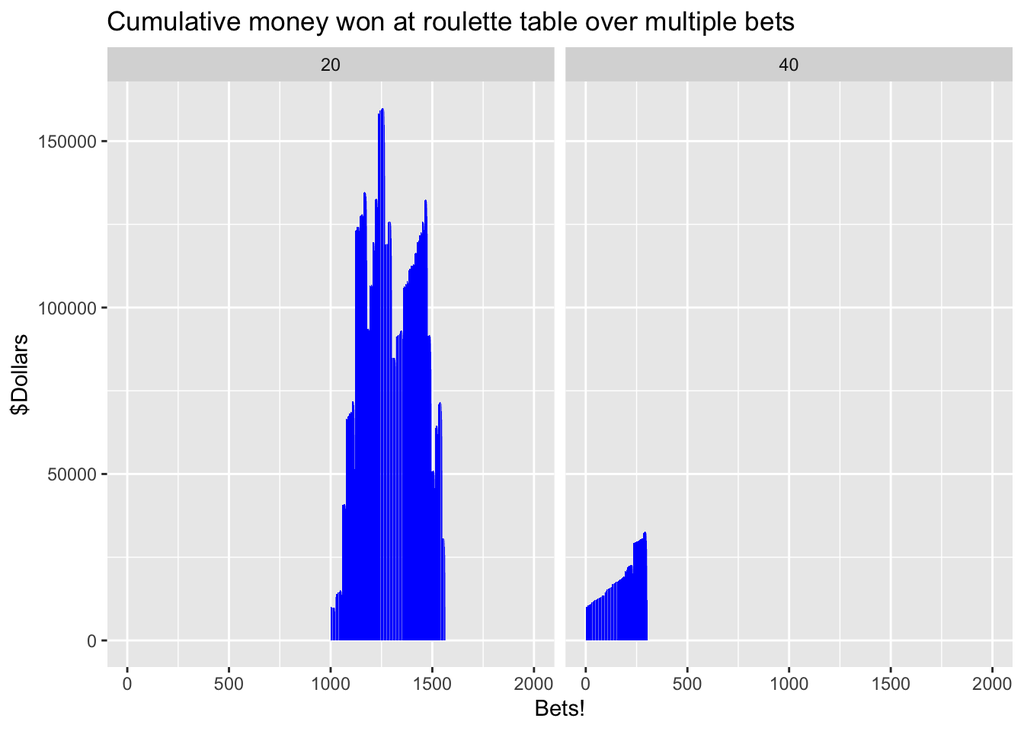

```r
plot4 = ggplot( rollsplot3 , aes(x = as.numeric(row.names(rollsplot3)), y=balance ))+ labs(title = "Cumulative money won at roulette table over multiple bets", x = "Bets!", y = "$Dollars") + geom_bar(stat = "identity",fill="blue") + facet_grid( ~percentage)
plot4
```

In order to produce this plot I did the same thing as Plot 3, but changed geom_point to geom_bar and included geom_bar’s arguments.